# 사망률 모형 이해를 위한 사전 작업

앞선 3가지 논문을 관통하는 핵심.

sonsungman https://sonsungman.github.io/SKKU-Preditive.m  
09-20-2021

### Introduction

미래 사망률을 예측하는 모형으로 다루게될 2가지 모형으로 Lee-Chater 모델과 2요인 평균회귀 모델이 있다. 이 모델에 대한 이해를 명확하게 하고 이 모델들에 베이지안 구조를 부여하여 MCMC기법을 통해 각 모수들의 사후 분포를 추정하면 모수 세트들을 얻을 수 있고 이를 활용해 다수의 미래 사망률 시나리오를 추정할 수 있다. 하지만 이 아이디어를 구현하는 것은 또 다른 문제라고 생각된다. 석사학위논문 주제였던 지급준비금 예측 분포 산출 주제에 있어서 MCMC기법을 활용하여 지급준비금에 대한 통계적 모델 속 모수들의 사후분포 추정 및 샘플링을 진행하였고 다수의 지급준비금 산출을 바탕으로 겅험적 분포를 산출해 이를 예측 분포로 보아 평균 지급준비금과 위험조정금액을 산출할 수 있었다. 동일한 프로세스가 진행될 것이라 볼 수 있다.

### 선행 연구에 대한 이해 필요성

사망률 모델에 대한 국내의 선행연구들을 읽어 나가야 앞서 제시한 3가지 논문들의 산출 결과를 볼 수 있을 것이다. 핵심을 사망률 모델에 대한 이해와 산출이 겠지만 그외에도 조재훈 교수님께서 작성하신 3번째 논문의 장수리스크 측정을 위한 장수채권에 대한 이해도 필요해 보인다. 물론 앞으로 도입될 K-ICS 4.0을 참고하면 장수리스크 관련 위험액 측정의 경우 전 보험기간 사망률 17.5% 감소시 순자산가치 변동액으로 측정하지만(즉, 충격 방식이다) 논문 상 장수리스크 측정에 장수 채권을 이용한 방법을 활용한 것을 볼 수 있다.

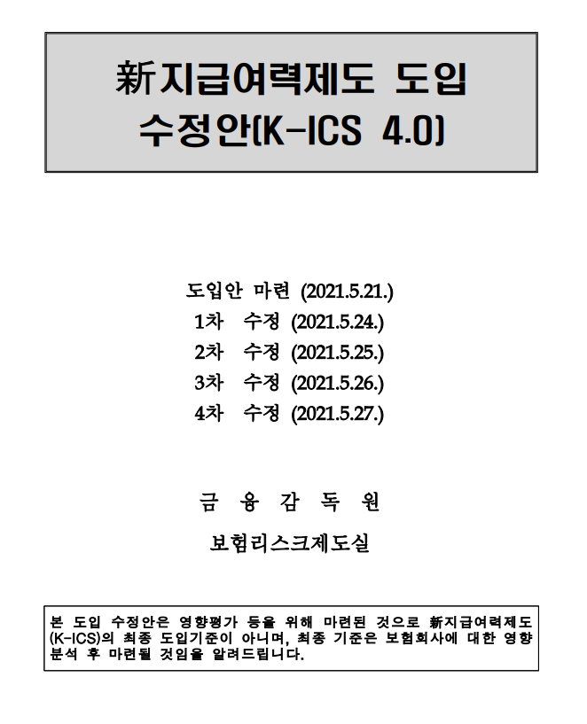

Figure 1: K-ICS 4.0 장수리스크 측정

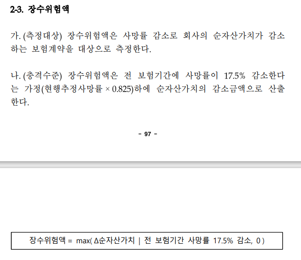

Figure 2: K-ICS 4.0 장수리스크 측정

### 선행연구들

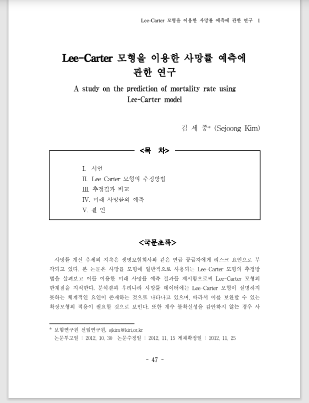

Figure 3: 선행연구 모음

[figure not shown]

Figure 4: 선행연구 모음

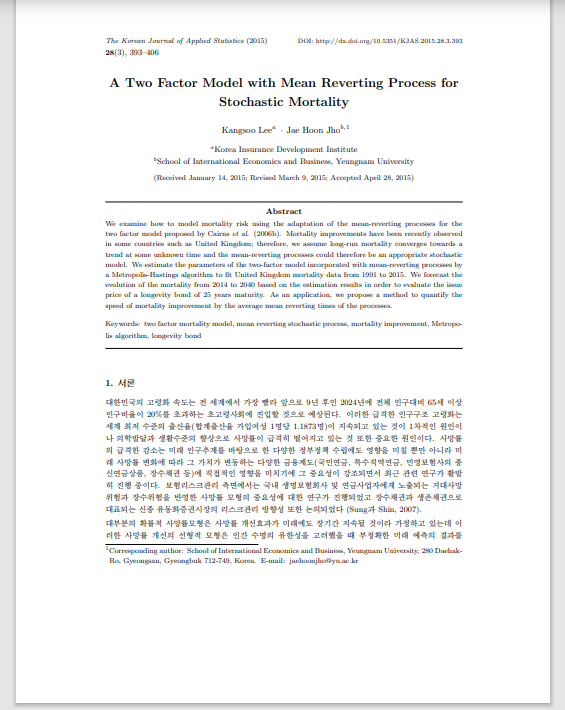

Figure 5: 선행연구 모음

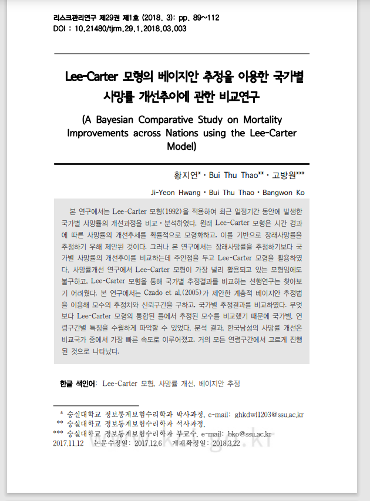

Figure 6: 선행연구 모음

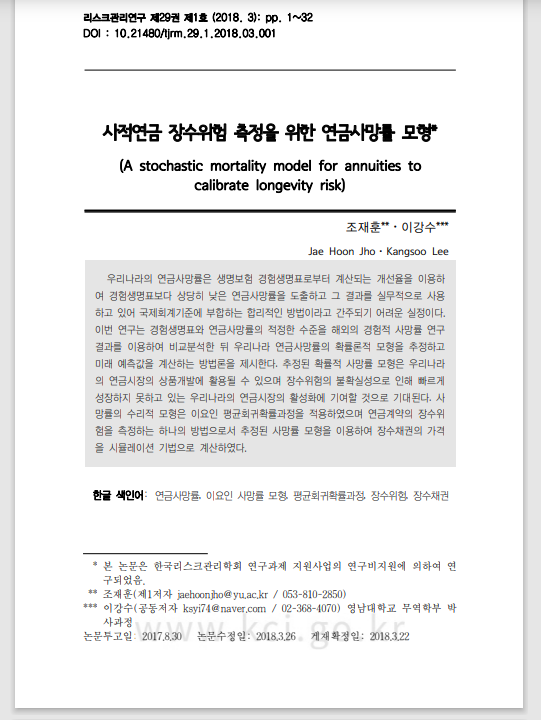

Figure 7: 선행연구 모음

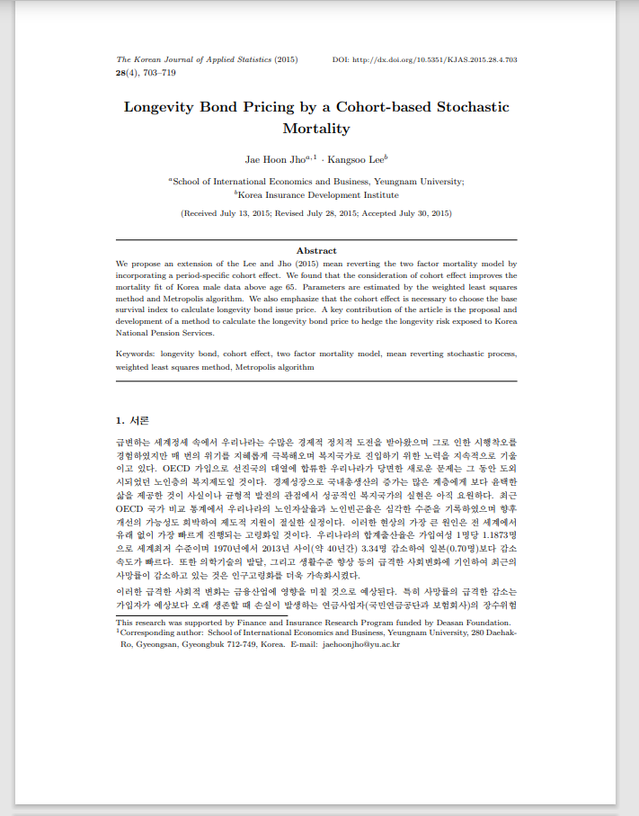

Figure 8: 선행연구 모음